# World of Tanks: Free to Play, Pay to Enjoy

Jeffrey Lyngdoh, January 10th 2024

### Introduction

Several months ago I created a Data Science Project based on World of Tanks, a video game I have sunk a lot of time into. After finishing and submitting said project for my intro course, [Found here](https://github.com/jeffreyLyngdoh/Final-Tutorial-World-of-Tank-deep-dive/blob/main/book.ipynb), I reflected on several points of improvement in analyzing data and testing the machine learning accuracy. This revamp of the original project is designed to implement these improvements as well as clarify certain concepts which were confusing or poorly explained. I hope to apply more meaningful techniques in order to better understand and interpret the game I like.

### What is World of Tanks?

Well to be blunt it is a tank game, a very popular one at that. Players are randomly assigned to teams where they battle other players. There are different types of battle ranging from capturing the other team's control point, attacking or defending a control point against another team, or destroying all enemy vehicles. Players may choose from a number of vehicle classes: light tanks, medium tanks, heavy tanks, tank destroyers, and self propelled guns. Each class has a specific role it is suited to. Feel free to read below for more information.

[Tank Class Roles](https://worldoftanks.com/en/content/guide/general/vehicle_types/)

Vehicles are grouped by nation and divided into 10 tiers. Each tier is basically a level of difficulty and experience with tier 1 composed of light tanks with machine guns and tier 10 being composed of cold war tanks.

There are a couple of ways to obtain tanks, the first way is earning then through the tech tree. This involves starting at tier 1 and moving up the tiers by earning experience and credits though battles. Another way is getting rewarded a tank this is usually done by completing missions or promotional events, there have been instances where WarGaming (company which owns WOT) has gifted tanks to all players for free. Another method involves saving up bonds (Special in game currency, cannot be bought) to buy tanks, this can take a while as bonds can only be earned through missions or battle passes. The last and perhaps least graceful way of obtaining a tank is spending money. This involves either buying a tank directly from the online store or buying loot boxes and hoping you get lucky.

[Here is an example of a tank tech tree](https://tanks.gg/techtree/france)  
[Here is WOT shop where you can buy tanks](https://na.wargaming.net/shop/wot/vehicles) (Don't recommded spending money)

### Premium Tanks

Tanks in addition to tiers and class tanks have the category of being considered Premium or Standard. Hopefully the term Premium is clear, these are tanks which are considered special by Wargaming. Premium tanks get more post battle reward than standard ones and as I hope to prove moving down, they are superior to standard ones in battles.

Well why have a distinction of Premium tanks at all? Well the key is how they are obtained, Premium tanks aren’t available in the tech tree, you can earn them by saving bonds, completing a missions or events, or most insightfully, buying them from the Wot store. Clear incentive structure here. Trying to earn a tank in game can take a while, offering a better vehicle for a price is a good way to earn money. If you really want to squeeze the consumer you can make a tank exclusively available to the online shop, or even better make them a rare item in a loot box.

### The Goal

The goal of this exercise is to highlight the advantage of Premium tanks over standard ones. Using data and static methods I hope to prove that Premium tanks are inherently superior to standard while at the same time disproving what I see as unfair assumptions. In addition I will use data relating tanks battle performance and economies to make a basic ML model which can predict a players profit based on performance in battle.

Outline

- Imports, Tools, Libaries
- Data Collection
- Premium V Standard
- Disproving Assumptions
- Feedback Loop
- Basic Machine learning
- Curation message

### Imports, Tools, Libaries

Have to admit to an abundance of imports used in my project. Tools for collecting and formatting data as well as models to test data.

```python
import requests
import json
from bs4 import BeautifulSoup
import pandas as pd
import matplotlib.pyplot as plt
import csv
from sklearn import linear_model
import numpy as np
from scipy import stats
import matplotlib.pyplot as plt
```

### Data Collection

World of Tank statistics can be found online. The website tomato.gg is a great website aggregating individual player statistics and overall tank statistics.

For example here are my stats: https://tomato.gg/stats/NA/Jeffrey1470%3D1020690095

I am a fairly average player I can compare my performance in a vehicle to the overall average: https://tomato.gg/tank-stats/NA/recent

It is at this point I have to make a decision regarding how to collect and work with this data. The tables with relevant information are embedded into the HTML of the website. There is no API as far as I could search. I resolved to gather the information by scraping the webpage as shown below. This is an issue as the structure and links to the relevant tables are often updated moving, a single tag can cause the information to be unavailable.

This brought up a couple questions for me:

- Revisiting this project in the future, do I always want to re-scrap the page?
- Do I want people exploring my work to do so?
- How can I maintain the links to the webpage or structure of the table if they change?
- Can the data changing cause my findings to become obsolete?

I decided the most practical thing is to work with a snap shot so to say. An analysis of the game at this moment in time (January 2024). I think highlighting the trends in the game at this moment in time is more tangible to my own experiences, I am a primary source of some of the trends I want to explore. The game is likely to change in the future, it will be interesting to see if my observations made right now continue into the future.

The method I used to scrape the web pages is shown below. There were two tables I was interested in. The first one shows tank stats which we will use to analyze tank performance in battles and the second one shows tank economies which we will use to build a basic ML alg.

The basic steps is we send a request to the link with the tables. We use BeautifulSoup to extract the HTML and a script to find the tag with the information. This script contains a JSON which we walk though to find the attribute with tank data. This information is then converted to and written to a csv file. In the cell examples below the results of scraping is written into output if you're curious to try it yourself. The data used as a snapshot for the rest of this project is written to the files in raw-data. Bear in mind running these cells may not work for reasons explained previously.

```python
url = "https://tomato.gg/tank-stats/NA/recent"

response = requests.get(url)
soup = BeautifulSoup(response.content, "html.parser")

script = soup.find("script", {"id": "__NEXT_DATA__"})

if script:
    contents = script.contents[0]
    data = json.loads(contents)

    initial_data = data["props"]["pageProps"]["data"]

    fieldnames = set()
    for obj in initial_data:
        fieldnames.update(obj.keys())

    filename = "output.csv"

    with open(filename, mode="w", newline="", encoding="utf-8") as file:
        writer = csv.DictWriter(file, fieldnames=list(fieldnames))
        writer.writeheader()
        writer.writerows(initial_data)
else:
    print("Error data not found")
```

```python
url = "https://www.tomato.gg/economics/all"
response = requests.get(url)
soup = BeautifulSoup(response.content, "html.parser")

script = soup.find("script", {"id": "__NEXT_DATA__"})
if script:
    contents = script.contents[0]
    data = json.loads(contents)
    initial_data = data["props"]["pageProps"]["data"]['data']

    fieldnames = set()
    for obj in initial_data:
        fieldnames.update(obj.keys())

    filename = "output.csv"

    with open(filename, mode="w", newline="", encoding="utf-8") as file:  # Specify UTF-8 encoding
        writer = csv.DictWriter(file, fieldnames=list(fieldnames))
        writer.writeheader()
        writer.writerows(initial_data)

else:
    print("Error data not found")
```

Once data is collected we can create Dataframes using pandas.

```python
generalDf = pd.read_csv("raw-data/general.csv")
economicDF = pd.read_csv("raw-data/economic.csv")
```

As we can see there is quite a few columns and rows.

```python
generalDf
```

|  | tank_id | damage | winrate | direct_hits | image | life_time | distance_traveled | player_winrate | spotting_assist | isPrem | ... | shots_fired | damage_received | base_capture_points | base_defense_points | name | winrate_differential | class | spots | wn8 | hit_rate |
| --- | --- | --- | --- | --- | --- | --- | --- | --- | --- | --- | --- | --- | --- | --- | --- | --- | --- | --- | --- | --- | --- |
| 0 | 53601 | 1328 | 49.69 | 6.50 | https://api.worldoftanks.com/static/2.71.0/wot... | 296 | 1275 | 51.80 | 275 | True | ... | 8.49 | 1300 | 0.60 | 0.36 | Type 63 | -2.11 | HT | 1.09 | 1300 | 76.55 |
| 1 | 23057 | 1637 | 49.95 | 5.40 | https://api.worldoftanks.com/static/2.71.0/wot... | 316 | 1080 | 51.33 | 303 | True | ... | 7.06 | 1833 | 0.99 | 0.29 | Tiger-Maus | -1.38 | HT | 0.74 | 1301 | 76.51 |
| 2 | 61505 | 593 | 50.56 | 3.70 | https://api.worldoftanks.com/static/2.66.0/wot... | 267 | 1732 | 50.96 | 1073 | True | ... | 5.07 | 779 | 0.96 | 0.42 | ELC EVEN 90 | -0.40 | LT | 3.14 | 1096 | 73.05 |
| 3 | 30465 | 1782 | 51.96 | 7.11 | https://api.worldoftanks.com/static/2.71.0/wot... | 325 | 1313 | 51.68 | 330 | True | ... | 9.06 | 1570 | 0.94 | 0.42 | Obj. 752 | 0.28 | HT | 0.96 | 1370 | 78.49 |
| 4 | 60225 | 1472 | 54.60 | 5.86 | https://api.worldoftanks.com/static/2.66.0/wot... | 299 | 1848 | 53.25 | 616 | True | ... | 7.82 | 1071 | 0.52 | 0.56 | Bourrasque | 1.35 | MT | 1.98 | 1848 | 74.93 |
| ... | ... | ... | ... | ... | ... | ... | ... | ... | ... | ... | ... | ... | ... | ... | ... | ... | ... | ... | ... | ... | ... |
| 721 | 417 | 240 | 50.00 | 35.66 | https://api.worldoftanks.com/static/2.66.0/wot... | 190 | 880 | 46.67 | 55 | False | ... | 69.38 | 306 | 2.64 | 0.29 | L6/40 | 3.33 | LT | 0.88 | 767 | 51.40 |
| 722 | 51841 | 130 | 36.70 | 26.84 | https://api.worldoftanks.com/static/2.66.0/wot... | 171 | 934 | 47.77 | 30 | True | ... | 47.68 | 326 | 0.43 | 0.22 | L-60 | -11.07 | LT | 0.97 | 411 | 56.30 |
| 723 | 60433 | 217 | 51.89 | 38.44 | https://api.worldoftanks.com/static/2.66.0/wot... | 195 | 910 | 48.53 | 43 | True | ... | 68.76 | 366 | 0.96 | 0.55 | Pz. II D | 3.36 | LT | 0.91 | 955 | 55.91 |
| 724 | 5665 | 279 | 44.23 | 18.96 | https://api.worldoftanks.com/static/2.66.0/wot... | 178 | 888 | 46.73 | 35 | False | ... | 30.33 | 323 | 2.10 | 0.34 | T2 Medium | -2.50 | MT | 1.03 | 1352 | 62.52 |
| 725 | 54865 | 293 | 53.40 | 69.50 | https://api.worldoftanks.com/static/2.66.0/wot... | 189 | 1158 | 49.19 | 38 | True | ... | 118.34 | 263 | 0.99 | 1.92 | Light VIC | 4.21 | LT | 1.30 | 1692 | 58.73 |

726 rows × 32 columns

```python
economicDF
```

|  | isPrem | tank_id | avg_ammo_cost | tier | avg_earnings | image | name | class | avg_consumables_cost | nation | cost_per_shot | avg_repair_cost | earnings_per_minute | profit_per_minute | battles | avg_profit |
| --- | --- | --- | --- | --- | --- | --- | --- | --- | --- | --- | --- | --- | --- | --- | --- | --- |
| 0 | True | 52129 | 23216 | 8 | 112120 | https://api.worldoftanks.com/static/2.71.0/wot... | Mars | MT | 6432 | Italy | 1735 | 7572 | 21454 | 14331 | 6321 | 74898 |
| 1 | True | 51105 | 21226 | 8 | 109205 | https://api.worldoftanks.com/static/2.66.0/wot... | Bisonte C45 | HT | 8121 | Italy | 2215 | 6210 | 21704 | 14637 | 25302 | 73645 |
| 2 | True | 44289 | 21504 | 8 | 108094 | https://api.worldoftanks.com/static/2.66.0/wot... | 703 II (122) | HT | 8313 | USSR | 2344 | 7419 | 21353 | 13997 | 46284 | 70857 |
| 3 | True | 32545 | 24035 | 8 | 109963 | https://api.worldoftanks.com/static/2.71.0/wot... | XM66F | TD | 8276 | USA | 2545 | 6858 | 20500 | 13197 | 52986 | 70792 |
| 4 | True | 43585 | 8086 | 8 | 94565 | https://api.worldoftanks.com/static/2.66.0/wot... | EBR 75 FL 10 | LT | 10866 | France | 685 | 5076 | 21458 | 16005 | 21266 | 70535 |
| ... | ... | ... | ... | ... | ... | ... | ... | ... | ... | ... | ... | ... | ... | ... | ... | ... |
| 746 | False | 15953 | 37268 | 10 | 50892 | https://api.worldoftanks.com/static/2.66.0/wot... | Badger | TD | 11747 | UK | 3295 | 20798 | 9337 | -3471 | 9399 | -18922 |
| 747 | True | 57937 | 48869 | 10 | 71752 | https://api.worldoftanks.com/static/2.66.0/wot... | T95/FV4201 | HT | 19085 | UK | 4293 | 26908 | 14031 | -4519 | 12802 | -23111 |
| 748 | False | 17729 | 41517 | 10 | 44536 | https://api.worldoftanks.com/static/2.66.0/wot... | Foch B | TD | 10767 | France | 3541 | 18629 | 8379 | -4962 | 7191 | -26377 |
| 749 | True | 46849 | 52414 | 10 | 71011 | https://api.worldoftanks.com/static/2.66.0/wot... | Obj. 279 (e) | HT | 21148 | USSR | 4434 | 25849 | 13935 | -5573 | 17030 | -28402 |
| 750 | True | 51729 | 63201 | 3 | 37731 | https://api.worldoftanks.com/static/2.66.0/wot... | Pz. II J | LT | 2957 | Germany | 384 | 689 | 8646 | -6671 | 1209 | -29116 |

751 rows × 16 columns

```python
print(generalDf.columns)
print(economicDF.columns)
```

```
Index(['tank_id', 'damage', 'winrate', 'direct_hits', 'image', 'life_time',
       'distance_traveled', 'player_winrate', 'spotting_assist', 'isPrem',
       'tracking_assist', 'damage_blocked', 'nation', 'big_image', 'survival',
       'frags', 'battles', 'pen_rate', 'potential_damage_received', 'tier',
       'penetrations', 'sniper_damage', 'shots_fired', 'damage_received',
       'base_capture_points', 'base_defense_points', 'name',
       'winrate_differential', 'class', 'spots', 'wn8', 'hit_rate'],
      dtype='object')
Index(['isPrem', 'tank_id', 'avg_ammo_cost', 'tier', 'avg_earnings', 'image',
       'name', 'class', 'avg_consumables_cost', 'nation', 'cost_per_shot',
       'avg_repair_cost', 'earnings_per_minute', 'profit_per_minute',
       'battles', 'avg_profit'],
      dtype='object')
```

### Premium V Standard

Lets how see if we can point out the superiority premium tanks over standard ones.

We start by splitting the general stat dataframe into premium and standard vehicles

```python
standardGeneralDF = generalDf[generalDf["isPrem"] == False]
PremGeneralDF = generalDf[generalDf["isPrem"] == True]
```

#### Winrate

Win Rate is probably the most intuitive measure of performance. We ask ourselves if Premium tanks have a higher win rate than standard ones? We start by comparing weighted averages. (weighted average takes into account number of battles, a tank with only one battle and 1 win will have a 100% winrate which can skew our average)

```python
averageStdWr = (standardGeneralDF['winrate'] * standardGeneralDF['battles']).sum() / standardGeneralDF['battles'].sum()
averagePremWr = (PremGeneralDF['winrate'] * PremGeneralDF['battles']).sum() / PremGeneralDF['battles'].sum()

print("Average Standard Winrate: " +  str(averageStdWr))
print("Average Premium Winrate: " +  str(averagePremWr))
```

```
Average Standard Winrate: 48.98025193861417
Average Premium Winrate: 50.3643044736656
```

We observe an almost 1.4% increase in winrate in Premium tanks over Standard ones. This is quite a large difference in a game where margins make the difference. Winrate is closely linked to WN8 which determines a player's respective skill and experience. A change of a single percent can move you up a Standard deviation.

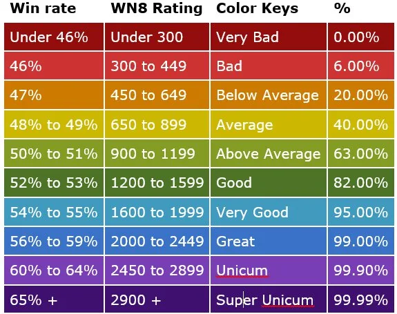

We can graph the average winrate by battles for a better picture

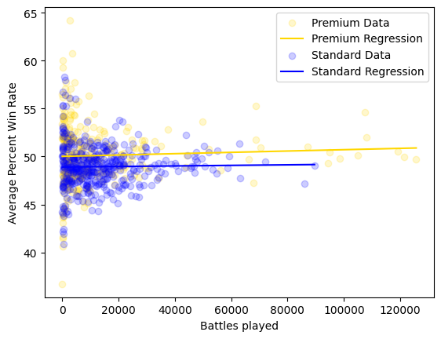

```python
reg = linear_model.LinearRegression()

x = np.array(PremGeneralDF['battles']).reshape(-1,1)
y = PremGeneralDF['winrate']
reg.fit(x,y)
predictions = reg.predict(x)
plt.scatter(x,y, alpha=0.2, label='Premium Data', color = "Gold")
plt.plot(x, predictions, color='Gold', label='Premium Regression')

x = np.array(standardGeneralDF['battles']).reshape(-1,1)
y = standardGeneralDF['winrate']
reg.fit(x,y)
predictions = reg.predict(x)
plt.scatter(x,y, alpha=0.2, label='Standard Data', color='blue')
plt.plot(x, predictions, color='blue', label='Standard Regression')

plt.xlabel('Battles played')
plt.ylabel('Average Percent Win Rate')
plt.legend()
plt.show()
```

Lets make our assumption that there is no meaningful difference between the win rate of Premium and standard vehicles. Our alternative being that Premium tanks have a higher winrate.

Null Hypothesis; There is no difference in winrate between Standard and Premium tanks  
Alternative Hypothesis: Premium tanks have a noticeably higher win rate compared to Standard ones.

```python
t_stat, p_val = stats.ttest_ind(standardGeneralDF['winrate'], PremGeneralDF['winrate'])
print("T-statistic:", t_stat)
print("P-value:", p_val)

if p_val < 0.05:
    print("Premium tanks have a noticeably higher win rate compared to Standard ones.")
    print("The premium tanks have a higher average winrate of:", averagePremWr)
else:
    print("There is not enough evidence to support a difference in winrates between standard and premium tanks.")
```

```
T-statistic: -5.790883518411311
P-value: 1.0435757469222936e-08
Premium tanks have a noticeably higher win rate compared to Standard ones.
The premium tanks have a higher average winrate of: 50.3643044736656
```

#### Damage Per Game

We now move to another aspect of battles, damage. The goal of a battle generally involves destroying enemy tanks so having more damage per game is a good indication of how well a tank performs.

A brief note here when measuring the difference between damage between Standard and Premiums we will split them up by tiers (1 - 10). Unlike winrate which is a binary win or not win, average damage per game varies widely from tier to tier. Tier 1 tanks usually expect a few hundred damage per game while Tiers 10s can reach 3000 average damage per game. We will therefore look at each tier individually, except for tier 1 as there are no Premium tanks in tier 1.

```python
for i in range(2, 11):
    standardGeneral = standardGeneralDF[standardGeneralDF['tier'] == i]
    premGeneral = PremGeneralDF[PremGeneralDF['tier'] == i]

    averageDamageStd = (standardGeneral['damage'] * standardGeneral['battles']).sum() / standardGeneral['battles'].sum()
    averageDamagePrem = (premGeneral['damage'] * premGeneral['battles']).sum() / premGeneral['battles'].sum()

    print(f"Tier {i} average damage: ")
    print(f"Average Weighted Damage Standard: {averageDamageStd}")
    print(f"Average Weighted Damage Prem: {averageDamagePrem}")
    print()
```

```
Tier 2 average damage:
Average Weighted Damage Standard: 293.039282440749
Average Weighted Damage Prem: 289.98760918139345

Tier 3 average damage:
Average Weighted Damage Standard: 302.7085757551606
Average Weighted Damage Prem: 368.9539064707545

Tier 4 average damage:
Average Weighted Damage Standard: 409.81775100461266
Average Weighted Damage Prem: 486.61425915447415

Tier 5 average damage:
Average Weighted Damage Standard: 471.6742697017389
Average Weighted Damage Prem: 582.2461186609214

Tier 6 average damage:
Average Weighted Damage Standard: 632.1110752468481
Average Weighted Damage Prem: 651.1980284405221

Tier 7 average damage:
Average Weighted Damage Standard: 729.010366081733
Average Weighted Damage Prem: 761.1885809582701

Tier 8 average damage:
Average Weighted Damage Standard: 927.2360867734225
Average Weighted Damage Prem: 1235.0756662562133

Tier 9 average damage:
Average Weighted Damage Standard: 1362.179587186423
Average Weighted Damage Prem: 1510.3042322498275

Tier 10 average damage:
Average Weighted Damage Standard: 1839.0416968342527
Average Weighted Damage Prem: 2043.4910715705448
```

Looking at the weighted averages we see the Premium tanks do seem to get more damage per game than standard ones, especially at higher tiers there is a larger gap.

We can once again graph these values. Below you can alter the tier variable to compare trends across each tier.

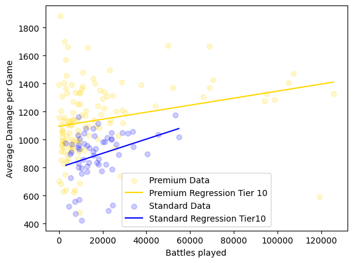

```python
tier = 8 #(Change this from range 1 - 10)

standardGeneral = standardGeneralDF[standardGeneralDF['tier'] == tier]
premGeneral = PremGeneralDF[PremGeneralDF['tier'] == tier]

reg = linear_model.LinearRegression()


x = np.array(premGeneral['battles']).reshape(-1,1)
y = premGeneral['damage']
reg.fit(x,y)
predictions = reg.predict(x)
plt.scatter(x,y, alpha=0.2, label='Premium Data', color = "Gold")
plt.plot(x, predictions, color='Gold', label=f'Premium Regression Tier {i}')

x = np.array(standardGeneral['battles']).reshape(-1,1)
y = standardGeneral['damage']
reg.fit(x,y)
predictions = reg.predict(x)
plt.scatter(x,y, alpha=0.2, label='Standard Data', color='blue')
plt.plot(x, predictions, color='blue', label=f'Standard Regression Tier{i}')

plt.xlabel('Battles played')
plt.ylabel('Average Damage per Game')
plt.legend()
plt.show()
```

Once again we can apply hypothesis testing. We will iterate each tier.

Null hypothesis: No meaning difference between average damage of Standard and Premium  
Alternative Hypothesis: Premium tanks have higher damage per game

```python
for i in range(2, 11):
    standardGeneral = standardGeneralDF[standardGeneralDF['tier'] == i]
    premGeneral = PremGeneralDF[PremGeneralDF['tier'] == i]

    t_stat, p_val = stats.ttest_ind(standardGeneral['damage'], premGeneral['damage'])
    print(f"Results of Tier {i}: ")
    print("T-statistic:", t_stat)
    print("P-value:", p_val)

    if p_val < 0.05:
        print("Premium tanks have higher damage per game")
        print(f"Prem have a higher average damage of {premGeneral['damage'].mean() - standardGeneral['damage'].mean()}")
    else:
        print("There is not enough evidence to support a difference in damage between standard and premium tanks.")

    print()
```

```
Results of Tier 2:
T-statistic: 0.5873280247965861
P-value: 0.5616901788418807
There is not enough evidence to support a difference in damage between standard and premium tanks.

Results of Tier 3:
T-statistic: -2.319091550461695
P-value: 0.024602574673928446
Premium tanks have higher damage per game
Prem have a higher average damage of 63.41428571428571

Results of Tier 4:
T-statistic: -1.9659467073955612
P-value: 0.05476002556497012
There is not enough evidence to support a difference in damage between standard and premium tanks.

Results of Tier 5:
T-statistic: -3.777497229746516
P-value: 0.00031791073279834357
Premium tanks have higher damage per game
Prem have a higher average damage of 100.4465949820788

Results of Tier 6:
T-statistic: -2.965613663905232
P-value: 0.00398060661802614
Premium tanks have higher damage per game
Prem have a higher average damage of 86.5250487963566

Results of Tier 7:
T-statistic: -2.3123594397097147
P-value: 0.02350375929984615
Premium tanks have higher damage per game
Prem have a higher average damage of 69.32727272727266

Results of Tier 8:
T-statistic: -6.781147961337474
P-value: 1.611648013188563e-10
Premium tanks have higher damage per game
Prem have a higher average damage of 249.46223728813573

Results of Tier 9:
T-statistic: -2.7836744207261637
P-value: 0.006638232610241437
Premium tanks have higher damage per game
Prem have a higher average damage of 195.7150537634409

Results of Tier 10:
T-statistic: -4.2102708711189045
P-value: 6.369317411834634e-05
Premium tanks have higher damage per game
Prem have a higher average damage of 411.778409090909
```

### Disproving Assumptions

Now we move onto disproving myths or rather attitudes so to say. There is a sense of resentment I’ve heard directed towards players who pay money to Wargaming, a sentiment that the game tweaks their numbers. People often lament that Premium tanks hit their shots more frequently than standard ones, even if the aim stat on the tank is similar. This notion basically suggests the game is more lenient with aiming when it comes to Premium tanks, giving hits it wouldn’t register to normal vehicles. I’ve always considered this attitude a bit unfair. While Premium tanks are certainly better than Standard ones, actually hitting shots is usually related to players skills. Better players are better able to predict enemy movement and be more precise with their shots.

Diving into this we can apply similar methods to above inorder to analyze hit rates between standard and non standard tanks. In this case I have opted to divide tanks based on class as roles usually play a role in this regard. SPGs shooting at range are more likely to miss shots compared to tank destroyers for example.

Diving into this we can apply similar methods to above inorder to analysis hit rates between standard and non standard tanks.

```python
generalGroupClass = generalDf.groupby("class")

for tank_class, group in generalGroupClass:
    print(f"Class {tank_class}")
    premGroup = group[group['isPrem'] == True]
    stdGroup = group[group['isPrem'] == False]
    print(f"Standard tanks hit rate mean: {stdGroup['hit_rate'].mean()}")
    print(f"Premium  tanks hit rate mean: {premGroup['hit_rate'].mean()}")
```

```
Class HT
Standard tanks hit rate mean: 72.512
Premium  tanks hit rate mean: 72.80833333333334
Class LT
Standard tanks hit rate mean: 62.87345238095238
Premium  tanks hit rate mean: 64.95
Class MT
Standard tanks hit rate mean: 65.356
Premium  tanks hit rate mean: 66.67301886792453
Class SPG
Standard tanks hit rate mean: 27.766046511627913
Premium  tanks hit rate mean: 27.619999999999997
Class TD
Standard tanks hit rate mean: 62.32458333333333
Premium  tanks hit rate mean: 64.28693877551021
```

Looking at the means these seem to be almost identical, lets apply hypothesis testing.

Null Hypothesis: There is no meaningful difference between hit rate of Premium and Standard tanks

Alternative Hypothesis: There is a difference between the two/

```python
for tank_class, group in generalGroupClass:
    print(tank_class)
    premGroup = group[group['isPrem'] == True]
    stdGroup = group[group['isPrem'] == False]
    t_stat, p_val = stats.ttest_ind(stdGroup['hit_rate'], premGroup['hit_rate'])


    if p_val < 0.05:
        print("There is a statistically significant difference in hit rate between standard and premium tanks.")
        print(f"Prem have a higher average damage of {premGeneral['damage'].mean() - standardGeneral['damage'].mean()}")
    else:
        print("There is not enough evidence to support a difference in hit rate between standard and premium tanks.")
```

```
HT
There is not enough evidence to support a difference in hit rate between standard and premium tanks.
LT
There is not enough evidence to support a difference in hit rate between standard and premium tanks.
MT
There is not enough evidence to support a difference in hit rate between standard and premium tanks.
SPG
There is not enough evidence to support a difference in hit rate between standard and premium tanks.
TD
There is not enough evidence to support a difference in hit rate between standard and premium tanks.
```

A similar attitude exists regarding damage blocked. The idea that shots are less likely to damage a Premium tank. This idea is a bit more understandable as some Premium do have truly overbearing armor. Hower blocking damage is also an attribute which is largely defined by player skill. The experience of Angling and Side-Scraping you tank to avoid taking damage.

You can learn about the machinic here: https://www.youtube.com/watch?v=uKtmnwIwrHc&t=755s

We apply similar method above this time grouping my tier

```python
for i in range(2, 11):
    standardGeneral = standardGeneralDF[standardGeneralDF['tier'] == i]
    premGeneral = PremGeneralDF[PremGeneralDF['tier'] == i]

    averageDamageStd = (standardGeneral['damage_blocked'] * standardGeneral['battles']).sum() / standardGeneral['battles'].sum()
    averageDamagePrem = (premGeneral['damage_blocked'] * premGeneral['battles']).sum() / premGeneral['battles'].sum()

    print(f"Tier {i}: ")
    print(f"Average Weighted Blocked Damage Standard: {averageDamageStd}")
    print(f"Average Weighted Blocked Damage Prem: {averageDamagePrem}")
    print()
```

```
Tier 2:
Average Weighted Blocked Damage Standard: 92.15909388503339
Average Weighted Blocked Damage Prem: 77.13833028641072

Tier 3:
Average Weighted Blocked Damage Standard: 81.60086076352913
Average Weighted Blocked Damage Prem: 76.63086323820288

Tier 4:
Average Weighted Blocked Damage Standard: 79.03869894302119
Average Weighted Blocked Damage Prem: 139.48209522269823

Tier 5:
Average Weighted Blocked Damage Standard: 96.9181605312656
Average Weighted Blocked Damage Prem: 129.97374212794168

Tier 6:
Average Weighted Blocked Damage Standard: 137.3908176422414
Average Weighted Blocked Damage Prem: 106.57511431481913

Tier 7:
Average Weighted Blocked Damage Standard: 235.88315020188682
Average Weighted Blocked Damage Prem: 114.46253302602732

Tier 8:
Average Weighted Blocked Damage Standard: 348.89838777601324
Average Weighted Blocked Damage Prem: 358.81711595137

Tier 9:
Average Weighted Blocked Damage Standard: 567.1393729278357
Average Weighted Blocked Damage Prem: 695.9399579579967

Tier 10:
Average Weighted Blocked Damage Standard: 700.3868127114066
Average Weighted Blocked Damage Prem: 761.9037351524114
```

Again we see similar values in some cases Standard tanks actually block more than Premium ones.

Let's confirm our results with Hypothesis testing.

```python
for i in range(2, 11):
    standardGeneral = standardGeneralDF[standardGeneralDF['tier'] == i]
    premGeneral = PremGeneralDF[PremGeneralDF['tier'] == i]

    t_stat, p_val = stats.ttest_ind(standardGeneral['damage_blocked'], premGeneral['damage_blocked'])
    print(f"Results of Tier {i}: ")
    print("T-statistic:", t_stat)
    print("P-value:", p_val)

    if p_val < 0.05:
        print("There is a statistically significant difference in damage blocked between standard and premium tanks.")
        print(f"Prem have a higher average damage blocked of {premGeneral['damage_blocked'].mean() - standardGeneral['damage_blocked'].mean()}")
    else:
        print("There is not enough evidence to support a difference in damage blocked between standard and premium tanks.")

    print()
```

```
Results of Tier 2:
T-statistic: 1.048494323126577
P-value: 0.3033773938305272
There is not enough evidence to support a difference in damage blocked between standard and premium tanks.

Results of Tier 3:
T-statistic: -0.8189173901487684
P-value: 0.41679870615352743
There is not enough evidence to support a difference in damage blocked between standard and premium tanks.

Results of Tier 4:
T-statistic: -2.709925271014741
P-value: 0.009143233362985234
There is a statistically significant difference in damage blocked between standard and premium tanks.
Prem have a higher average damage blocked of 87.25813953488371

Results of Tier 5:
T-statistic: -2.7699550468448257
P-value: 0.007083590307525099
There is a statistically significant difference in damage blocked between standard and premium tanks.
Prem have a higher average damage blocked of 98.89749103942653

Results of Tier 6:
T-statistic: 0.13214641983695957
P-value: 0.8952002784426245
There is not enough evidence to support a difference in damage blocked between standard and premium tanks.

Results of Tier 7:
T-statistic: -0.43415721546748154
P-value: 0.665420726377952
There is not enough evidence to support a difference in damage blocked between standard and premium tanks.

Results of Tier 8:
T-statistic: -2.218293883624952
P-value: 0.0277716313954561
There is a statistically significant difference in damage blocked between standard and premium tanks.
Prem have a higher average damage blocked of 123.79037288135595

Results of Tier 9:
T-statistic: -0.4687346420280653
P-value: 0.6404735176434123
There is not enough evidence to support a difference in damage blocked between standard and premium tanks.

Results of Tier 10:
T-statistic: -1.0683907691715089
P-value: 0.28840502578320093
There is not enough evidence to support a difference in damage blocked between standard and premium tanks.
```

In a majority of tiers its there is not enough evidence to suggest Premium tanks have an advantage in this regard.

### Feedback Loop

The feedback loop: Do good players make Premum tanks appear better than standard ones or do Premium tanks allow for average players preform better?

As the query above suggests I had a bit of a quandary regarding some of the tends I noticed. Do Premium tanks get better damage and higher win rates because they are so much better than standard ones or is it because they are being played by better players? Let's break down my thought process.

Who uses Premium tanks? There are two means of acquiring a Premium, earning it game or buying one. Earning a tank in game take a lot of time. This can require weeks or even months or earning items such as bonds (in game currency you cannot buy, you earn through missions) or completing missions. This certainly requires a bit of dedication, acquiring several Premium could take years. Buying a Premium is straightforward just go onto the game website, put in credit card details and it is yours. It is conceivable that if a person is willing to spend money on a tank they are quite delicate to the game long term. The point here is that players who use Premium tanks often are more likely to be experienced and skilled at the game, as a consequence Premium may appear much better than normal ones due to having a better player base.

Why get a Premium? The above point one may assume better players are causing the tends highlighted in the previous part. But it raise a simple question, why would players commit to obtaining Premium tanks in the first place, well the most initiative answer is they are simply better than standard ones. Features of tanks such as Armor, Damage, Penetration, etc are all available online it is simple to compare different vehicles. It is fairly straightforward to determine if one tank is better than another. There is a clear incentive to make Premium tanks better, as a reward for players hard work, or a cash grab, players won't spend money on a tank unless they think it good.

```python
url = "https://tomato.gg/stats/EU/skill4ltu%3D503233015?tab=tanks"

response = requests.get(url)
soup = BeautifulSoup(response.content, "html.parser")

script = soup.find("script", {"id": "__NEXT_DATA__"})

if script:
    contents = script.contents[0]
    data = json.loads(contents)
    initial_data = data['props']['pageProps']['overallStats']['data']['tanks']

    fieldnames = set()
    for obj in initial_data:
        fieldnames.update(obj.keys())

    filename = "output.csv"

    with open(filename, mode="w", newline="", encoding="utf-8") as file:
        writer = csv.DictWriter(file, fieldnames=list(fieldnames))
        writer.writeheader()
        writer.writerows(initial_data)
else:
    print("Error data not found")
```

```python
personalDf = pd.read_csv("raw-data/personal.csv")
personalDf
```

|  | isPrem | dmgratio | hitratio | kd | nation | winrate | spots | moe | xp | image | ... | tier | bigImage | kpg | class | awards | armoreff | name | dpg | survival | dpgRanking |
| --- | --- | --- | --- | --- | --- | --- | --- | --- | --- | --- | --- | --- | --- | --- | --- | --- | --- | --- | --- | --- | --- |
| 0 | False | 1.89 | 79 | 1.91 | france | 65.97 | 4.17 | 3 | 1101 | https://api.worldoftanks.com/static/2.71.0/wot... | ... | 8 | https://api.worldoftanks.com/static/2.71.0/wot... | 1.37 | LT | {'battleHeroes': {'highCaliber': 5, 'topGun': ... | 0.00 | Lynx 6x6 | 1561 | 28.47 | NaN |
| 1 | False | 1.35 | 83 | 1.94 | uk | 62.02 | 1.63 | 3 | 1056 | https://api.worldoftanks.com/static/2.71.0/wot... | ... | 8 | https://api.worldoftanks.com/static/2.71.0/wot... | 1.28 | HT | {'battleHeroes': {'highCaliber': 16, 'topGun':... | 0.57 | Caernarvon | 1840 | 34.13 | NaN |
| 2 | True | 1.74 | 74 | 2.63 | germany | 68.24 | 3.01 | 3 | 985 | https://api.worldoftanks.com/static/2.71.0/wot... | ... | 5 | https://api.worldoftanks.com/static/2.71.0/wot... | 1.82 | MT | {'battleHeroes': {'highCaliber': 10, 'topGun':... | 0.14 | Pz. III K | 905 | 30.59 | NaN |
| 3 | False | 2.17 | 83 | 3.41 | ussr | 62.38 | 1.37 | 3 | 1279 | https://api.worldoftanks.com/static/2.71.0/wot... | ... | 9 | https://api.worldoftanks.com/static/2.71.0/wot... | 1.89 | HT | {'battleHeroes': {'highCaliber': 20, 'topGun':... | 1.13 | Obj. 257 | 3479 | 44.55 | NaN |
| 4 | False | 1.92 | 73 | 1.52 | france | 66.67 | 1.52 | 0 | 588 | https://api.worldoftanks.com/static/2.71.0/wot... | ... | 4 | https://api.worldoftanks.com/static/2.71.0/wot... | 1.06 | MT | {'battleHeroes': {'highCaliber': 3, 'topGun': ... | 0.09 | SARL 42 | 505 | 30.30 | NaN |
| ... | ... | ... | ... | ... | ... | ... | ... | ... | ... | ... | ... | ... | ... | ... | ... | ... | ... | ... | ... | ... | ... |
| 765 | True | 1.96 | 82 | 2.88 | poland | 62.28 | 1.46 | 3 | 1314 | https://api.worldoftanks.com/static/2.71.0/wot... | ... | 8 | https://api.worldoftanks.com/static/2.71.0/wot... | 1.75 | HT | {'battleHeroes': {'highCaliber': 14, 'topGun':... | 0.54 | 56TP | 2782 | 39.47 | NaN |
| 766 | False | 1.69 | 73 | 1.94 | ussr | 65.09 | 4.20 | 3 | 755 | https://api.worldoftanks.com/static/2.71.0/wot... | ... | 5 | https://api.worldoftanks.com/static/2.71.0/wot... | 1.42 | LT | {'battleHeroes': {'highCaliber': 4, 'topGun': ... | 0.12 | T-50 | 551 | 26.42 | NaN |
| 767 | False | 2.18 | 75 | 3.38 | sweden | 70.54 | 2.39 | 3 | 1313 | https://api.worldoftanks.com/static/2.71.0/wot... | ... | 8 | https://api.worldoftanks.com/static/2.71.0/wot... | 1.69 | MT | {'battleHeroes': {'highCaliber': 10, 'topGun':... | 0.05 | UDES 14 5 | 2473 | 50.00 | NaN |
| 768 | False | 4.13 | 57 | 3.77 | france | 59.76 | 0.60 | 0 | 400 | https://api.worldoftanks.com/static/2.71.0/wot... | ... | 2 | https://api.worldoftanks.com/static/2.71.0/wot... | 2.16 | TD | {'battleHeroes': {'topGun': 4, 'confederate': ... | 0.14 | FT AC | 324 | 42.68 | NaN |
| 769 | True | 1.92 | 68 | 3.53 | ussr | 70.00 | 1.66 | 3 | 1196 | https://api.worldoftanks.com/static/2.71.0/wot... | ... | 7 | https://api.worldoftanks.com/static/2.71.0/wot... | 1.89 | HT | {'battleHeroes': {'highCaliber': 20, 'topGun':... | 0.47 | IS-2M | 1987 | 46.36 | NaN |

770 rows × 24 columns

We can divid this data into Premium and standard dataframes

```python
presonalPrem = personalDf[personalDf['isPrem'] == True]
presonalStd = personalDf[personalDf['isPrem'] == False]
```

```python
print(f"Average DPG Premium {(presonalPrem['wn8'] * presonalPrem['battles']).sum() / presonalPrem['battles'].sum()}")
print(f"Average DPG Standard {(presonalStd['wn8'] * presonalStd['battles']).sum() / presonalStd['battles'].sum()}")
```

```
Average DPG Premium 4102.790552275095
Average DPG Standard 3465.518556623691
```

```python
t_stat, p_val = stats.ttest_ind(presonalPrem['wn8'], presonalStd['wn8'])
print(p_val)
if p_val < 0.05:
    print("There is a statistically significant difference in damage between standard and premium tanks.")
    print(f"Prem have a higher average damage of {premGeneral['damage_blocked'].mean() - standardGeneral['damage_blocked'].mean()}")
else:
    print("There is not enough evidence to support a difference in damage between standard and premium tanks.")
```

[output not shown]

### Machine learning

Goal - Predict Players Profit in battle based on stats provided after battle and information on vehicle and vehicle cost they played:

After a battle players can look at stats detailing their actions in battle and profit here is an example.

[figure not shown]

[figure not shown]

There are 3 main metrics used to determine how much profit a player will earn after a battle. As shown in post battle results.

- The players performance in battle, things like how much damage they dealt or blocked, how many kills did they get, did they win? Etc
- The type of Tank they played. Heavy or light? Premium or standard?
- The tanks' consumable cost, the game will deduct earnings for ammunition used in each shot. Using health kits and repairing vehicle

We want to take information regarding a players tank and their actions in battle as detailed above to make a prediction regarding their profit. (total attribute on bottom right)

To do this we will combine columns in the general and economic df, determine which columns are relevant to the post battle results and use these to construct a basic prediction model

Lets start by examining the columns in each dataframes.

```python
print(generalDf.columns)
print(economicDF.columns)
```

```
Index(['tank_id', 'damage', 'winrate', 'direct_hits', 'image', 'life_time',
       'distance_traveled', 'player_winrate', 'spotting_assist', 'isPrem',
       'tracking_assist', 'damage_blocked', 'nation', 'big_image', 'survival',
       'frags', 'battles', 'pen_rate', 'potential_damage_received', 'tier',
       'penetrations', 'sniper_damage', 'shots_fired', 'damage_received',
       'base_capture_points', 'base_defense_points', 'name',
       'winrate_differential', 'class', 'spots', 'wn8', 'hit_rate'],
      dtype='object')
Index(['isPrem', 'tank_id', 'avg_ammo_cost', 'tier', 'avg_earnings', 'image',
       'name', 'class', 'avg_consumables_cost', 'nation', 'cost_per_shot',
       'avg_repair_cost', 'earnings_per_minute', 'profit_per_minute',
       'battles', 'avg_profit'],
      dtype='object')
```

We can combind them using common column values and drop null values (inner join shouldn't actually have any)

```python
combind_data = pd.merge(generalDf, economicDF, on = ['tank_id', 'name', 'isPrem', 'class', 'tier', 'nation'], how='inner')
combind_data = combind_data.dropna()
```

We will then perform a bit of clean up so to say. Turning non numeric columns into numeric representations and altering values for convenience.

- For class attribute (heavy tank, light tank, SPG, etc) we assign each possible class as a column represented with either 1 or 0, (class_LT 1), (class_HT 0), etc
- For isPrem simply make 1 if the tank is premium and 0 if not.
- In the most match stats we see all assistance damage combined into “damage due to player assistance” attribute. We can therefore add an assistance column to dataframe by adding tracking and spotting assist.
- We can make penetrate into a decimal between 0 and 1 as post battle stats treats display them as whole number which can be represented as fractions (penetrations) / (shots fired)

```python
combind_data = pd.get_dummies(combind_data, columns=['class'])
combind_data['isPrem'] = combind_data['isPrem'].apply(lambda x : 1 if x else 0)
combind_data['assistance'] = combind_data['tracking_assist'] + combind_data['spotting_assist']
combind_data['pen_rate'] = combind_data['pen_rate'] * 0.01
```

We will now partition our data with relevant columns into a training set and a testing set, this will help us avoid overmatching.

```python
training_data = combind_data.loc[0:349, ['avg_profit', 'winrate', 'damage', 'damage_blocked', 'pen_rate', 'assistance', 'frags', 'spots', 'isPrem', 'class_HT', 'class_LT', 'class_MT',
       'class_SPG', 'class_TD', 'tier', 'avg_ammo_cost', 'avg_consumables_cost', 'avg_repair_cost']]
testing_data = combind_data.loc[350:, ['avg_profit', 'winrate', 'damage', 'damage_blocked', 'pen_rate', 'assistance', 'frags', 'spots', 'isPrem', 'class_HT', 'class_LT', 'class_MT',
       'class_SPG', 'class_TD', 'tier', 'avg_ammo_cost', 'avg_consumables_cost', 'avg_repair_cost']]
```

```python
testing_data
```

|  | avg_profit | winrate | damage | damage_blocked | pen_rate | assistance | frags | spots | isPrem | class_HT | class_LT | class_MT | class_SPG | class_TD | tier | avg_ammo_cost | avg_consumables_cost | avg_repair_cost |
| --- | --- | --- | --- | --- | --- | --- | --- | --- | --- | --- | --- | --- | --- | --- | --- | --- | --- | --- |
| 350 | 43577 | 48.37 | 999 | 632 | 0.6809 | 430 | 0.62 | 1.22 | 1 | 0 | 0 | 1 | 0 | 0 | 8 | 22025 | 8714 | 7366 |
| 351 | 11839 | 48.47 | 661 | 470 | 0.6724 | 196 | 0.64 | 0.64 | 0 | 1 | 0 | 0 | 0 | 0 | 6 | 15358 | 4231 | 5865 |
| 352 | 3389 | 52.19 | 539 | 143 | 0.5889 | 96 | 1.06 | 0.48 | 0 | 0 | 0 | 0 | 0 | 1 | 4 | 14781 | 3847 | 1149 |
| 353 | 10886 | 48.37 | 635 | 197 | 0.6375 | 290 | 0.58 | 0.95 | 0 | 0 | 0 | 1 | 0 | 0 | 7 | 15164 | 4787 | 7298 |
| 354 | 3431 | 49.94 | 1540 | 583 | 0.6952 | 328 | 0.88 | 0.66 | 0 | 0 | 0 | 0 | 0 | 1 | 9 | 31796 | 7530 | 11600 |
| ... | ... | ... | ... | ... | ... | ... | ... | ... | ... | ... | ... | ... | ... | ... | ... | ... | ... | ... |
| 714 | 13402 | 46.77 | 307 | 7 | 0.1289 | 40 | 0.70 | 0.03 | 0 | 0 | 0 | 0 | 1 | 0 | 3 | 940 | 1422 | 541 |
| 715 | 2251 | 56.52 | 1392 | 382 | 0.7391 | 517 | 1.06 | 1.33 | 1 | 0 | 0 | 1 | 0 | 0 | 8 | 22914 | 1362 | 12031 |
| 716 | 2884 | 36.70 | 130 | 21 | 0.3852 | 37 | 0.21 | 0.97 | 1 | 0 | 1 | 0 | 0 | 0 | 2 | 10182 | 1483 | 411 |
| 717 | 896 | 51.89 | 217 | 63 | 0.4955 | 56 | 0.48 | 0.91 | 1 | 0 | 1 | 0 | 0 | 0 | 2 | 19186 | 639 | 436 |
| 718 | 15036 | 53.40 | 293 | 21 | 0.4733 | 54 | 1.01 | 1.30 | 1 | 0 | 1 | 0 | 0 | 0 | 2 | 116 | 1496 | 330 |

369 rows × 18 columns

We not need to determine theta values. In machine learning, theta (often represented as the Greek letter θ) plays a crucial role by representing the parameters of a model. These parameters act like knobs or dials that the learning algorithm twists and turns to make the model fit the data better.

We use theta values in a hypothesis equation which is meant to provide a reasonable guess.

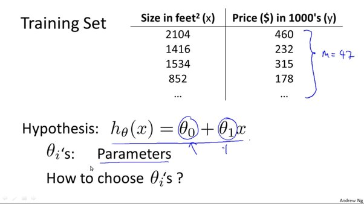

To do this we will employ gradient descent, imagine you're lost in a hilly landscape, trying to find the lowest valley, which represents the best solution to a problem. Gradient descent is like your guide, helping you navigate downhill towards the valley floor. The valley floor in this case is the set of theta values which result in the lowest amount of errors. You are constantly tweaking the theta values trying to get to the lowest point.

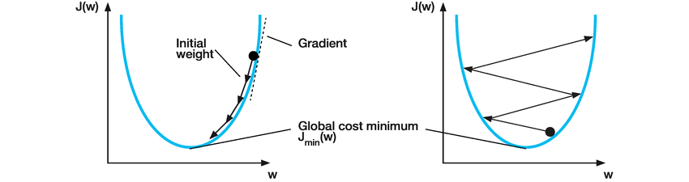

```python
def grad_descent(X, y, T, alpha, lambda_=0.0001):
    m, n = X.shape
    theta = np.zeros(n)
    f = np.zeros(T)

    for i in range(T):
        error = X.dot(theta) - y
        regularization_term = lambda_ * np.linalg.norm(theta, 2)**2  # L2 regularization
        f[i] = 0.5 * np.linalg.norm(error)**2 + regularization_term

        # Calculate the gradient with respect to theta
        g = X.T.dot(error) + 2 * lambda_ * theta  # Gradient with L2 regularization

        # Update theta using the gradient and the learning rate
        theta = theta - alpha * g

    return theta, f
```

We can then call our function by playing around with the alpha and T values to get the fit. We also standardize our training data to lower the time and cost of calculating values. When we apply these to attributes to a prediction function we will need to remember to normalize them

```python
y = training_data['avg_profit'].values
X = training_data.drop("avg_profit", axis=1).values

X_mean = np.mean(X, axis=0)
X_std = np.std(X, axis=0)
X = (X - X_mean) / X_std

X = np.hstack((np.ones((X.shape[0], 1)), X))
```

```python
T= 5000
alpha=0.0001
theta, f = grad_descent(X, y, T, alpha)
print(theta)
```

```
[ 15628.93106918   1675.84104567   5478.0272403    6282.93834796
   7517.94487619   2061.65992865  -1496.50589394  -3845.28292593
   9649.08124525   2454.58072549  -1266.08549387    732.001284
   3299.98066852  -4679.36531029  16329.07239711  -7952.42430583
   2402.98091202 -29406.83335516]
```

We can plot our loss, distance to min over each iteration.

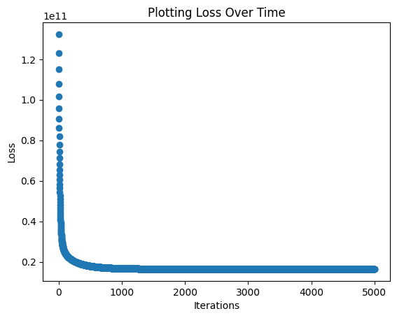

```python
plt.scatter(range(T), f)
plt.title('Plotting Loss Over Time')
plt.xlabel('Iterations')
plt.ylabel('Loss')
```

```python
training_data.columns
```

```
Index(['avg_profit', 'winrate', 'damage', 'damage_blocked', 'pen_rate',
       'assistance', 'frags', 'spots', 'isPrem', 'class_HT', 'class_LT',
       'class_MT', 'class_SPG', 'class_TD', 'tier', 'avg_ammo_cost',
       'avg_consumables_cost', 'avg_repair_cost'],
      dtype='object')
```

With these theta values we can now construct a prediction function which takes user information and makes a guess as to users expected profit.

Recall we need to normalize our attribute values to match gradient descent alteration.

```python
def normalize(name, value, data):
    return (value - data[name].mean()) / data[name].std()
```

In our prediction function we iterate through each attribute value and normalize them. We place these values into a feature array which is dot produced with theta values. This sum should be a reasonable prediction.

```python
def predictProfit(attr_name, attr_values, data, theta):
    profit = 0

    features = [1]

    if(len(attr_name) == len(attr_values)):
        index = 0

        while index < len(attr_name):

            features.append(normalize(attr_name[index], attr_values[index], data))

            index += 1

        profit = np.dot(features, theta)


    return profit
```

Lets now test this out on one of my own battles. This is a game I won playing a tier 8 heavy tank which was premium. My profit from the game was 66409 credits.

[figure not shown]

Plugging in information from the game we can see the result is about 57000 which is quite a reasonable guess.

```python
# 1 for a win, 0 for loss
win = 1

# total damage caused
damage = 3400

# penetrations / total shots fired
pen_rate = 13 / 20

# damage blocked by armor
damage_blocked = 4160

# damage cause with your assistance
assistance = 0

# enemy tanks destroyed
frags = 4

# enemy tanks spotted
spots = 0

# tier of your tank
tier = 8

# class of your tank
class_HT = 1
class_LT = 0
class_MT = 0
class_SPG = 0
class_TD = 0

# 1 if prem, 0 if std
isPrem = 1

# credit spent resupply ammunition
ammo_cost = 26000

# credits spend consumables
consumable_cost = 0

# repair cost
repair_cost = 9000

attr_name = training_data.columns.to_list()
attr_name.pop(0)

attr_values = [win, damage, damage_blocked, pen_rate, assistance, frags, spots, isPrem, class_HT, class_LT, class_MT, class_SPG, class_TD, tier, ammo_cost, consumable_cost, repair_cost]

predictProfit(attr_name, attr_values, combind_data, theta)
```

```
56703.31206806321
```

Variance and Bias

Now applying our prediction function on our testing set we can observe the variance and bias in the number of errors. We want a low bias indicating lower errors and low variance to ensure we are not overfitting.

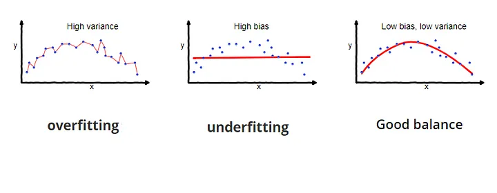

```python
def apply_predict(row):

    values = row.tolist()

    values.pop(0)

    return predictProfit(attr_name, values, combind_data, theta)

prediction_values = testing_data.apply(apply_predict, axis=1)
```

After calculating errors from each row of the testing set we can observe our bias and variance to be reasonably low. Tweaking the iterations and step values in gradient descent can lower or raise these accordingly. I personally feel I have found a good balance.

```python
bias = (testing_data['avg_profit'] - prediction_values).mean()
variance = np.sqrt(((testing_data['avg_profit'] - prediction_values) ** 2).mean())

print(f"Bias of testing set: {bias}")
print(f"Variance of testing set {variance}")
```

```
Bias of testing set: -1544.6033291930041
Variance of testing set 12155.50563337925
```

### Curation message

Hopefully my work has provided a brief insight into some of the issues surrounding the world of tanks. We analyze the advantage premium tanks have over normal ones which is only a single factor in the larger issue of advantaging paying players over players who don’t.

Now it is understandable that WarGaming is a company and they need to earn money however doing so at the expense of other players is not a fair or sustainable practice.

Newer players can become discouraged and frustrated by some of these blatant favoritism and it breeds a sense of resentment within the player base.

Winrates and credits ought to be based on skill and performance within a battle rather than whether a tank is paid for or not. I think an important chance Wargaming should make is really rewarding players based on consistency.

Players that are able to acquire several premium tanks are able to quick acquire large sums of credits that they can use to speed run though the tech tree, use more expensive ammo, play higher tiers, and overall have an advantage over other players. This can be discouraging especially for newer players.

Making Premium tanks better than standard ones may be somewhat fair however in battles Wargaming should work to ensure an even number of premium tanks on both sides. This can make games more fair and even out the large difference in winrate between premium and non premium tanks.

Code Source

Examples from my class lecture we utilized in parts of this project. The linear Gradient function was one as well as some of the linear models. In addition, more tedious parts of the project were assisted with chatGPT. This includes the initial web page scraping and conversion to CSV as well as some of the hypothesis testing.

Possible improvements

The project certainly can be made better in a number of ways.

First of all the tank data I am using is not always up to data as the API I use can be unreliable. Finding a way to work around this so that the data is always somewhat reasonably up to date is a valid concern.

Combining the data frames containing general and economic data can cause data to be lost when joined. Perhaps I could use my prediction function to try and fill in lost information rather than dropping them.

There are other issues in my project I won’t go too in-depth in. Overall the project was able to convey my primary purpose. In the future I may revisit this project and make adjustments.